# Take-home exercise: Programming in R

(with solutions)

## 1 Learning Goals

- strengthen programming skills for statistical work
- work confidently with objects, functions, and control flow
- prepare for further programming and modeling in Stan

## 2 Linear Algebra Basics in R

Scalars, vectors, and matrices are frequently used objects in linear algebra.

Unfortunately, they do not translate straightforwardly into numeric R objects.

### 2.1 Scalars

A scalar is a single numeric element (e.g., an integer or a real number).

R does **not** have an object type for scalars. Scalars are stored as numeric vectors of length 1.

Of course, it is not that easy. In math, the inner product of two vectors returns a scalar:

$$s = \mathbf{a}^{\prime} \mathbf{b} =
\begin{bmatrix} 0.5 & 1 & 1.5\end{bmatrix} \begin{bmatrix} 1 \\
2 \\ 3 \end{bmatrix} = 0.5 \times 1 + 1 \times 2 + 1.5 \times 3 =
7$$

In R, however,…

…`s` will be stored as a matrix of dimensions $1 \times 1$. This can be annoying, because it prevents you from using `s` for simple tasks like scalar multiplication:

$$7 \begin{bmatrix} 1 & 3 \\ 2 &
4\end{bmatrix} = \begin{bmatrix} 7 & 21 \\ 14 &
28\end{bmatrix}$$

### 2.2 Vectors

Whereas the mathematical concept of a scalar is stored as a `vector` object in R, the mathematical concept of a vector *sometimes* requires the object type `matrix`.

We usually distinguish row and column vectors in linear algebra. Row vectors are matrices of dimensions $1 \times K$ whereas column vectors are matrices of dimensions $K \times 1$.

So, `a %*% b`, same as the more literal `t(a) %*% b`, yields the inner product $\mathbf{a}^{\prime} \mathbf{b}$.

### 2.3 Summary

In R:

- Scalars are vectors, and sometimes matrices.
- Vectors are column vectors, but sometimes act like row vectors, and can be defined as matrices.
- Matrices are, in fact, matrices.

Why is this important?

- Stan’s programming language does not allow for these imprecisions
- We will therefore need to be mindful about the *actual* classes and dimensions of our objects and about how we pass R generated data to Stan.

## 3 Implementing OLS in R

We have all used the ordinary least squares estimator for linear regression. But have you ever implemented it from scratch? This will be your task for this exercise!

Note that we will not *derive* the OLS estimator by hand. Instead, you will get the derivation and translate it into R code.

### 3.1 The linear model

The OLS estimator for linear regression requires calculations in matrix form.

### 3.2 Model specification:

Likelihood:
$$\mathbf{y}_i \sim
\text{N}(\mu_i, \sigma^2) \text{ for all }i = 1,...N$$

Systematic component:
$$\mu_i =
\mathbf{x}_i^{\prime} \beta \text{ for all }i = 1,...N$$

### 3.3 Four ways to denote the linear model formula

1. Scalar form:
   $$y_i = \beta_1 x_{i1} +
   \beta_2 x_{i2} + \beta_3 x_{i3} + \epsilon_i \text{ for all }
   i=1,...,N$$
2. Row-vector form:
   $$y_i =
   \mathbf{x_i^{\prime}} \mathbf{\beta} + \epsilon_i \text{ for all }
   i=1,...,N$$
3. Column-vector form:
   $$\mathbf{y} =
   \beta_1 \mathbf{x_{1}} + \beta_2 \mathbf{x_{2}} + \beta_3 \mathbf{x_{3}}
   + \mathbf{\epsilon}$$
4. Matrix form:
   $$\mathbf{y = X \beta +
   \epsilon}$$

### 3.4 What the matrix-form looks like in detail

$$\underbrace{\begin{bmatrix} y_1 \\ \vdots \\ y_{N} \end{bmatrix}}_{N
\times 1}
=
\underbrace{\begin{bmatrix}
1 & x_{1, 2} & \cdots & x_{1, K} \\
\vdots & \vdots & \ddots & \vdots \\
1 & x_{N, 2} & \cdots & x_{N, K}
\end{bmatrix}}_{N \times K}
\underbrace{\begin{bmatrix} \beta_1 \\ \beta_2 \\ \vdots \\
\beta_K \end{bmatrix}}_{K \times 1}
+
\underbrace{\begin{bmatrix} \epsilon_1 \\ \vdots \\ \epsilon_{N}
\end{bmatrix}}_{N \times 1}$$

### 3.5 The matrix form is 100% equivalent to the other three forms

$$\underbrace{\begin{bmatrix} y_1 \\ \vdots \\ y_{N} \end{bmatrix}}_{N
\times 1}
=
\underbrace{\begin{bmatrix}
\beta_1 \cdot 1 + \beta_2 \cdot x_{1, 2} + \cdots + \beta_K \cdot
x_{1, K} \\
\vdots \\
\beta_1 \cdot 1 + \beta_2 \cdot x_{N, 2} + \cdots + \beta_K \cdot
x_{N, K} \\
\end{bmatrix}}_{N \times 1}
+
\underbrace{\begin{bmatrix} \epsilon_1 \\ \vdots \\ \epsilon_{N}
\end{bmatrix}}_{N \times 1}$$

### 3.6 Inputs (data)

1. A length-$N$ outcome vector $\mathbf{y}$
2. An $N \times K$ model matrix $\mathbf{X}$, which contains a leading column of 1’s to multiply the intercept

### 3.7 Primary outputs (estimands, parameters)

1. A length-$K$ coefficient vector $\beta$
2. A real, strictly positive variance parameter $\sigma^2$

### 3.8 Secondary outputs (transformed parameters)

With estimates $\hat{\beta}$ and $\hat{\sigma}^2$, we can directly calculate the variance-covariance matrix of the coefficients, $\hat{\mathbf{\Sigma}}$. This variance-covariance matrix gives us the parameters that define the joint multivariate normal *sampling distribution* of our coefficients:
$$\hat{\beta} \sim \text{MVN}(\hat{\beta}, \hat{\mathbf{\Sigma}})$$

Some things to note:

- The diagonal of this matrix holds the *variances* of our coefficients.
- The square root of these variances gives us their *standard errors*.
- The off-diagonals give us the *covariances* of any pair of coefficients.
- The variance-covariance matrix is of dimensions $K \times K$.
- The variance-covariance matrix is *symmetrical*; thus $\Sigma_{a,b} = \Sigma_{b, a}$ for any $a, b \in \{1,...,K\}$.

## 4 Data preparation

### 4.1 Context

The exercise chunk has pre-loaded the data frame `gles`, which contains three variables from the 2017 German Longitudinal Election Study. We want to model respondents’ support for the AfD (`sup_afd`, measured on an 11-point scale ranging from -5 to 5) as a function of respondents’ pro-redistribution preferences (`se_self`) and anti-immigration preferences (`la_self`), including a multiplicative interaction term for the two predictors (`se_self:la_self`).

Both `se_self` and `la_self` are measured on 11-point scales:

- `se_self` ranges from values (0) “less taxes and deductions, even if that means less social spending” to (10) “more social spending, even if that means more taxes and deductions”.
- `la_self` ranges from values (0) “facilitate immigration” to (10) “restrict immigration”.

The model formula is given by
$$\mathtt{sup\_afd} = \beta_1 + \beta_2
\mathtt{se\_self} + \beta_3 \mathtt{la\_self} + \beta_4 \mathtt{se\_self
\times la\_self} + \epsilon$$

### 4.2 Prompt

The task is simple: We need the vector $\mathbf{y}$ and the matrix $\mathbf{X}$

Hints:

- You can extract any column from a data frame using the `$` operator.
- Check out `model.matrix()`, which takes the right-hand of a model formula as input and returns a complete model matrix.

```r
y <- gles$sup_afd
X <- model.matrix(~ se_self + la_self + se_self:la_self, data = gles)
```

## 5 Estimation

### 5.1 The coefficient vector

You have probably seen this before: The OLS estimator for $\beta$ is given by

$$\hat{\beta} = \mathbf{(X^{\prime}X)^{-1}X^{\prime}y}$$

Let’s translate this into R! Hints:

- `t()` transposes matrices/vectors
- `solve()` inverts matrices
- `%*%` multiplies matrices/vectors

```r
b <- solve(t(X) %*% X) %*% t(X) %*% y
```

### 5.2 The variance parameter

The estimator for the variance parameter $\sigma^2$ is
$$\hat{\sigma}^2 =
\frac{\mathbf{e}^{\prime}\mathbf{e}}{N-K}$$

Here, $\mathbf{e}$ is a length-$N$ vector of residuals, where $\mathbf{e} = \mathbf{y} - \mathbf{X}\beta$, which is the same as $\mathbf{e} = \mathbf{y} - \hat{\mathbf{y}}$.

For this task, first calculate $\mathbf{e}$. Then, calculate $\hat{\sigma}^2$. After this, you can calculate the variance-covariance matrix, which is given by
$$\hat{\mathbf{\Sigma}} = \hat{\sigma}^2
\mathbf{(X^{\prime}X)^{-1}}$$

Hints:

- Remember that X is of dimensions $N \times K$. Try `dim()`, `nrow()`, and `ncol`.
- Check the structure (`str()`) of `e`.
- Check the `class()` of `sigma2`. You want it to be of a vector of class `numeric`.

```r
e <- y - X %*% b
N <- nrow(X)
K <- ncol(X)
sigma2 <- t(e) %*% e / (N - K)
Sigma <- as.vector(sigma2) * solve(t(X) %*% X)
```

### 5.3 A basic regression table

With $\hat{\beta}$ and $\hat{\mathbf{\Sigma}}$, we can calculate the standard errors of our coefficients, which are given by the square root of the diagonal of $\hat{\mathbf{\Sigma}}$.

Using these, we can also calculate 95% confidence intervals for our coefficients, which are given by $\hat{\beta} + \Phi^{-1}(0.025) \cdot \text{SE}(\hat{\beta})$ and $\hat{\beta} + \Phi^{-1}(0.975) \cdot \text{SE}(\hat{\beta})$. Here $\Phi^{-1}$ is the quantile function of the standard normal distribution, which you can calculate with `qnorm()`.

```r
tibble::tibble(
  term = c("Intercept", "se_self", "la_self", "se_self:la_self"),
  estimate = as.vector(b),
  std_error = sqrt(diag(Sigma)),
  conf_low = estimate + qnorm(.025) * std_error,
  conf_high = estimate + qnorm(.975) * std_error
)
```

```
## # A tibble: 4 × 5
##   term            estimate std_error conf_low conf_high
##   <chr>              <dbl>     <dbl>    <dbl>     <dbl>
## 1 Intercept        -4.61     0.390   -5.38     -3.85
## 2 se_self          -0.128    0.0646  -0.255    -0.00148
## 3 la_self           0.292    0.0538   0.186     0.397
## 4 se_self:la_self   0.0123   0.00916 -0.00566   0.0302
```

### 5.4 Validation

Let’s check if we got everything right!

Estimate the model via `lm()` and extract the coefficient vector and the variance-covariance matrix of the coefficients.

Then, use `all.equal()` with the option `check.attributes = FALSE` to check if our estimates differ from those generated via `lm()`. Note that you must supply identical object types, so convert `b` to a `vector`.

```r
# Estimate model
est_lm <- lm(sup_afd ~ se_self + la_self + se_self:la_self, data = gles)

# Extract b and Sigma
b_lm <- coef(est_lm)
Sigma_lm <- vcov(est_lm)

# Check for equality (with minor tolerance)
all.equal(as.vector(b), b_lm, check.attributes = FALSE)
```

```
## [1] TRUE
```

```r
all.equal(Sigma, Sigma_lm, check.attributes = FALSE)
```

```
## [1] TRUE
```

## 6 Bonus: Processing (prediction)

With $\hat\beta$ and $\hat{\mathbf{\Sigma}}$, we have knowledge of the full sampling distribution for $\hat\beta$. This allows us to also get confidence intervals for any post-estimation quantities of interest that are functions of parameters and data.

We are going to focus on *expected values*: $\mathbb{E}[y|\mathbf{\mathbf{x}^{\ast}}] = \mathbf{x}^{\ast\prime}\hat\beta$. The vector $\mathbf{x}^{\ast}$ can contain any (reasonable) scenario of covariate values. Here, we want to calculate expected values over the full grid of values of `se_self` and `la_self`.

How can we get its standard error? In OLS models, the variance of an expected value is given by

$$\mathbf{x}^{\ast \prime}
\hat{\mathbf{\Sigma}} \mathbf{x}^{\ast}$$

Its square root gives the standard error.

### 6.1 Step 1: Define value sequences for the predictors

Remember that both predictors are measured on 11-point scales ranging from 0 to 10. But that shouldn’t stop us from calculating at finer gradations of the two scales. Define value sequences ranging from 0 to 10 in steps of 0.25 for both predictors (Hint: `seq()`) and store them in the vectors below.

```r
se_vals <- seq(0, 10, .25)
la_vals <- seq(0, 10, .25)
```

### 6.2 Step 2: Initialize a container

Before we start, let’s be clear what we want eventually: For every value combination of `se_vals` and `la_vals`, we want three estimates:

1. The point estimate of the expected value, $\mathbf{x}^{\ast \prime} \hat \beta$
2. The lower bound of its confidence interval, $\mathbf{x}^{\ast \prime} \hat \beta + \Phi^{-1}(0.025) \sqrt{\mathbf{x}^{\ast \prime}\hat{\mathbf{\Sigma}} \mathbf{x}^{\ast}}$
3. The upper bound of its confidence interval, $\mathbf{x}^{\ast \prime} \hat \beta + \Phi^{-1}(0.975) \sqrt{\mathbf{x}^{\ast \prime}\hat{\mathbf{\Sigma}} \mathbf{x}^{\ast}}$

So our container must accommodate `length(se_vals) * length(la_vals) * 3L = 5043L` values.

We could, of course, store these in a vector of length 5043. Or in three matrices of dimensions $41 \times 41$, which we could subsequently wrap in a list. Let’s go for the most convenient solution, though: A three-dimensional `array` of dimensions `dim = c(length(se_vals), length(la_vals), 3L)`. Let’s initialize this object with `NA`s.

```r
pred <- array(NA, dim = c(length(se_vals), length(la_vals), 3L))
```

### 6.3 Step 3: Use a nested loop to fill the container

Hints:

- Your outer loop should loop through the elements of `se_vals` (see `seq_along()`).
- Your inner loop should loop through the elements of `la_vals` (see `seq_along()`).
- Define (overwrite) the vector `x_star` at each iteration of the loop. Remember that our model matrix has four columns – you will need a corresponding vector element in `x_star`:
  1. a 1 to multiply the intercept
  2. the $i^{\text{th}}$ value of `se_self`
  3. the $j^{\text{th}}$ value of `la_self`
  4. the product of the $i^{\text{th}}$ value of `se_self` and the $j^{\text{th}}$ value of `la_self`
- Define (overwrite) the vector `std_error` at each iteration of the loop. Remember: You want this to be a *scalar*!

```r
for (i in seq_along(se_vals)) {
  for (j in seq_along(la_vals)) {
    x_star <- c(1, se_vals[i], la_vals[j], se_vals[i] * la_vals[j])
    std_err <- sqrt(as.vector(t(x_star) %*% Sigma %*% x_star))
    pred[i, j, 1] <- x_star %*% b
    pred[i, j, 2] <- pred[i, j, 1] + qnorm(.025) * std_err
    pred[i, j, 3] <- pred[i, j, 1] + qnorm(.975) * std_err
  }
}
```

## 7 Visualization

Time for some shameless self-promotion: We are going to use my `regplane3D` package to visualize the expected values of AfD support as a joint function of socio-economic and immigration preferences.

These plots generalize two-dimensional plots that show expected values/predictions as a line that varies with one predictor to three dimensions, where the expected values/predictions are shown as a plane that varies with two predictors. You can find additional information [here](https://socialsciencedatalab.mzes.uni-mannheim.de/article/regplane3d/).

```r
regplane3D::plane3D(
  z = pred,
  x = se_vals,
  y = la_vals,
  main = "Expected AfD Support \n by Redistribution and Immigration Preferences",
  zlab = "Support AfD",
  xlab = "Pro-Redistribution",
  ylab = "Anti-Immigration",
  xnlines = 6L,
  ynlines = 6L
)
```

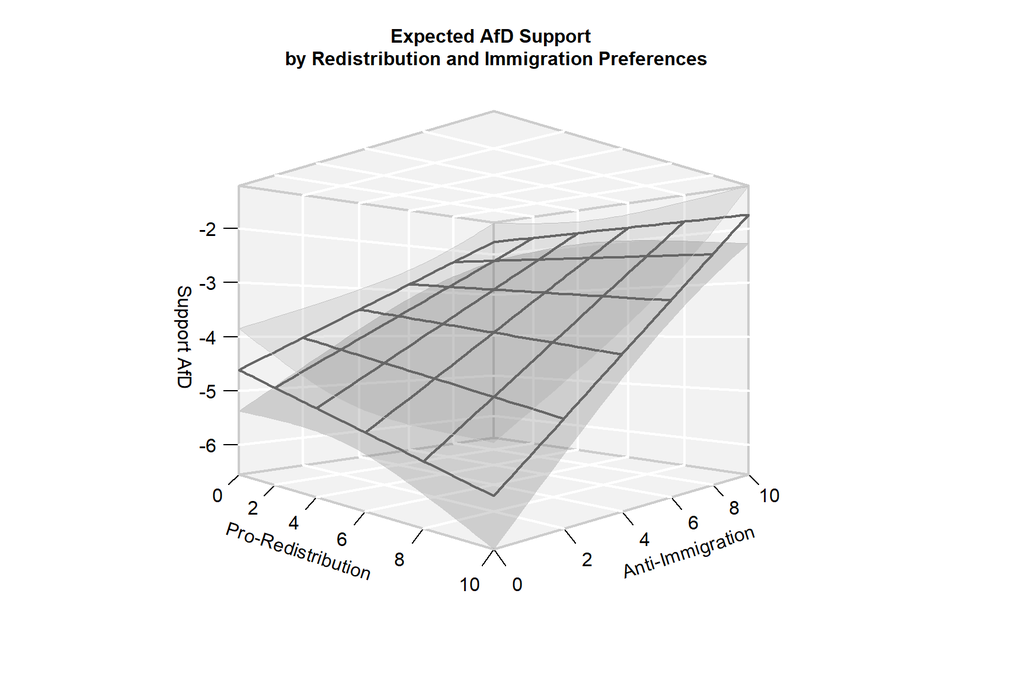

So, which substantive conclusions can we draw?